# Cranberry Models: Common Control

## 1) Introduction

Crop production and harvest is an area of study whose output affects every general population. This is becuase everyone, regardless of their different facets of life - need to consume food to survive. With the growing trend of global temperature, food production and harvest quantity may fluctuate.

This study aims answer question about the effects of heat treatment to cranberries and result we observe in production of cranberries.

We aim of answer the following questions :

1. How does heat stress affect yield as measured by the total weight of fruit?
2. How does heat stress affect yield as measured by the total weight of healthy fruit?
3. How does heat stress affect yield as measured by the percentage of healthy berries by count?
4. How does heat stress affect yield as measured by the percentage of healthy fruit by weight?
5. How do the cultivars, years, and intensity of the heat shocks (in the case of the acute heat stress experiment) affect the various measures of yield?

## 2) Exploratory Data Analysis and Modifications

Let us visualize the data first

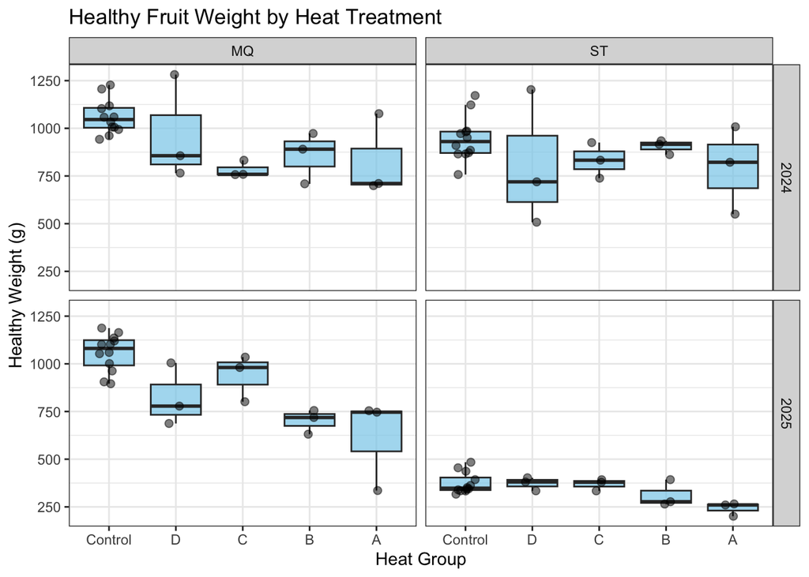

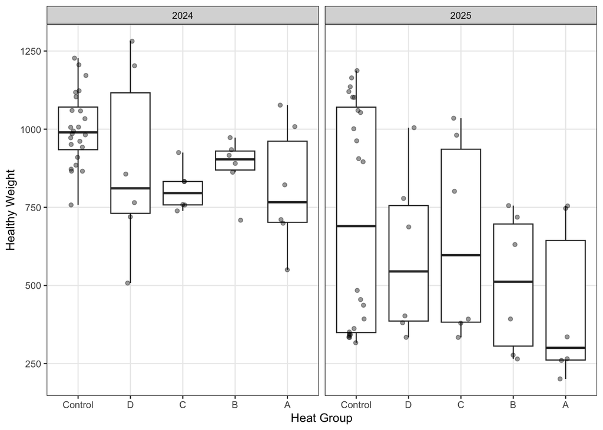

```r
ggplot(data, aes(x = factor(heat_group), y = healthy_weight)) +
  geom_boxplot(outlier.shape = NA) +
  geom_jitter(width = 0.15, alpha = 0.4, color = "black") +
  facet_wrap(~ year) + # Split into separate panels by year
  labs(x = "Heat Group", y = "Healthy Weight") +
  theme_classic() +
  theme_bw(base_size = 10) +
  theme(
    plot.title = element_text(face = "bold", hjust = 0.5),
    panel.grid.minor = element_blank()
  )
```

Healthy Fruit Proportion by Heat Treatment

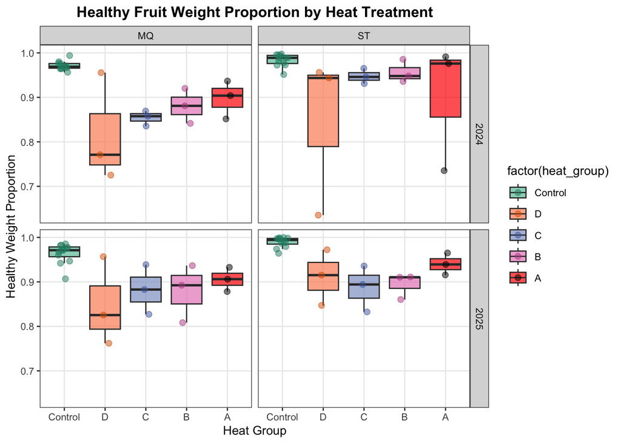

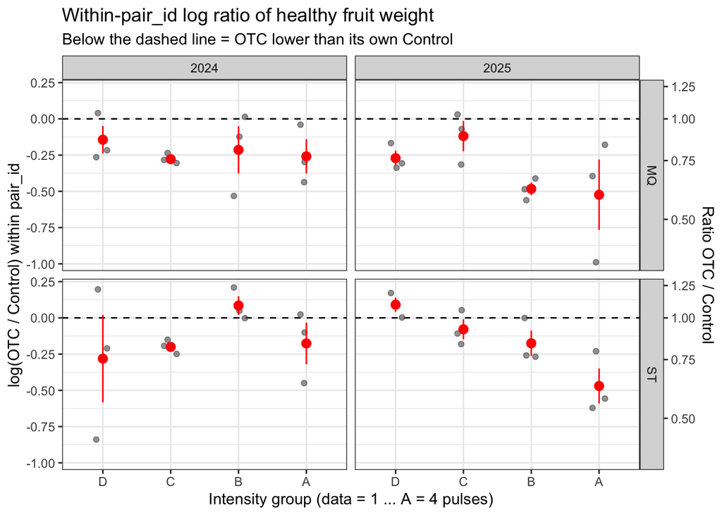

We can observe from this plot that in majority of the cases, the production of heat treated group is in general lower than the log transformed control cases.

With the said data visualizations, we can observe how correlated the characteristics of the study are.

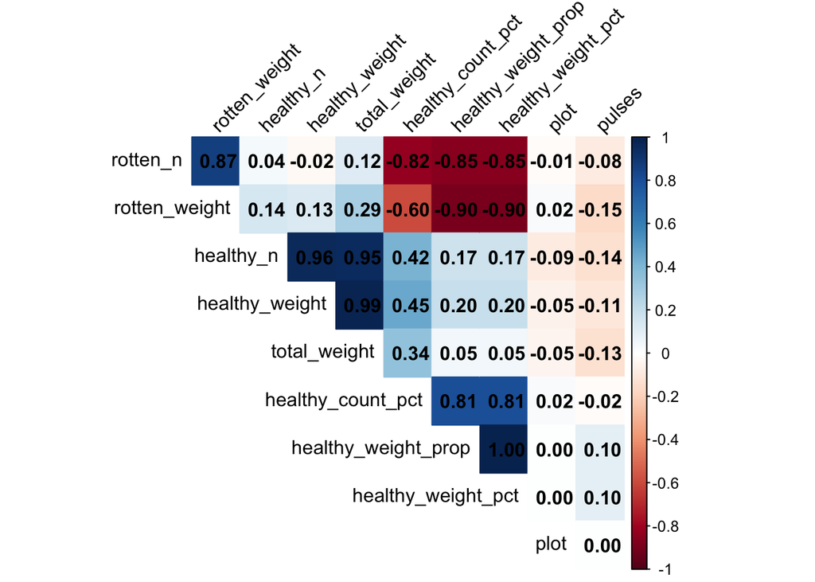

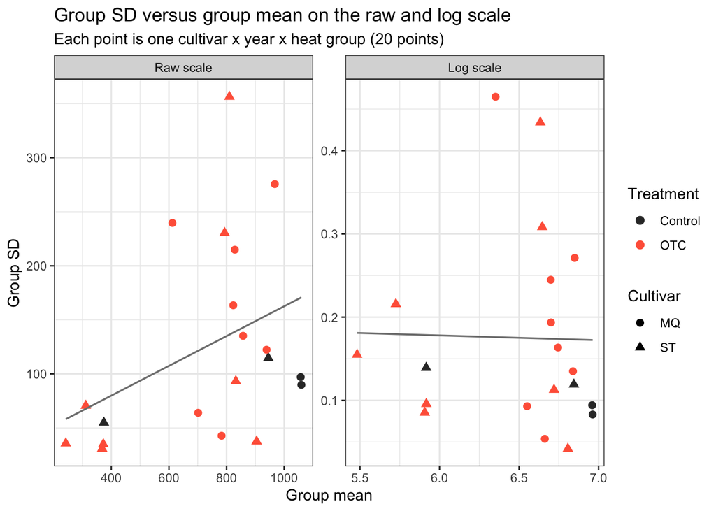

The relationship between group means and standard deviations was examined on both the original and logarithmic scales to assess potential mean-dependent variability. On the original scale, a positive association was observed between group means and standard deviations, suggesting that variability increased with average healthy fruit weight. Following logarithmic transformation, this relationship became substantially weaker, indicating that the transformation may improve variance stability. Therefore, a log transformation was considered as a potential approach for addressing heteroscedasticity in subsequent statistical modeling.

Testing the density distribution of Total Weight

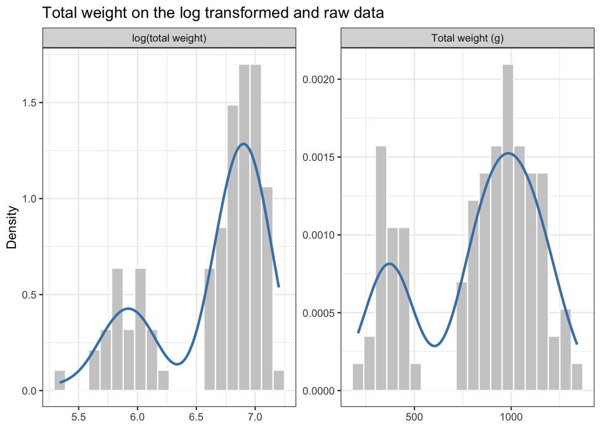

Log transformations fix right-skewness—they cannot fix bimodality

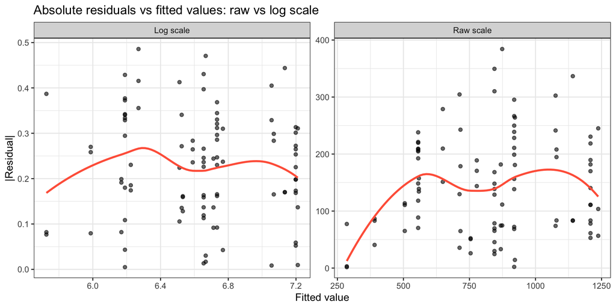

Absolute residuals vs fitted values from a Gaussian model. The raw scale shows a mild increase in spread with the fitted value; the log scale is flatter. This supports modelling log(total weight).

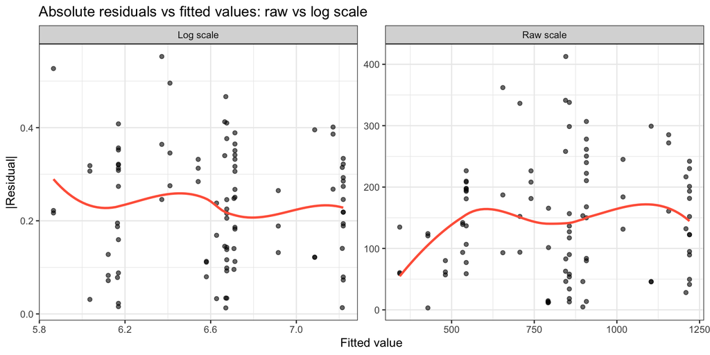

Absolute residuals vs fitted values from a Gaussian model. The raw scale shows a mild increase in spread with the fitted value; the log scale is flatter. This supports modelling log(total weight).

While log transformation was unable to address the bimodial nature of total weight distribution, it looks like it stabalizes variance.

## 3) Interations

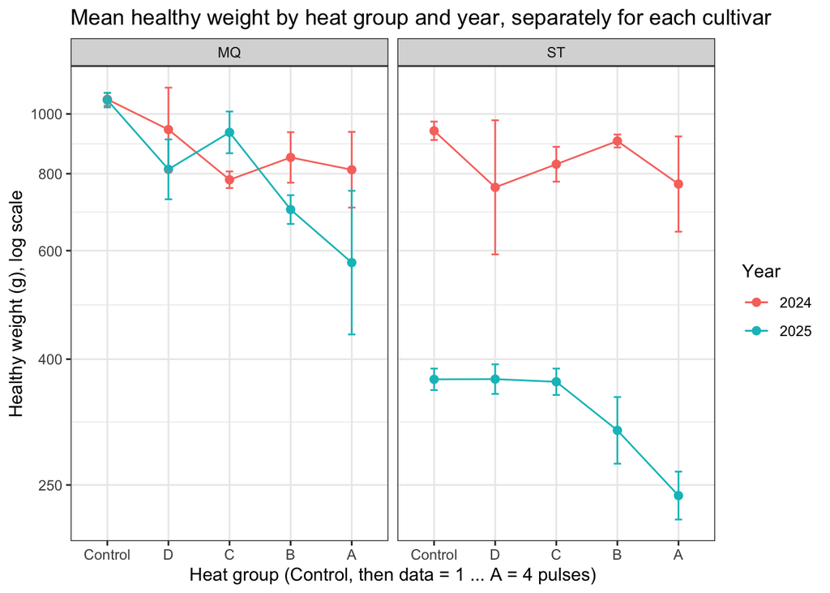

A key potential statistical interaction in this dataset is a Cultivar × Year interaction.

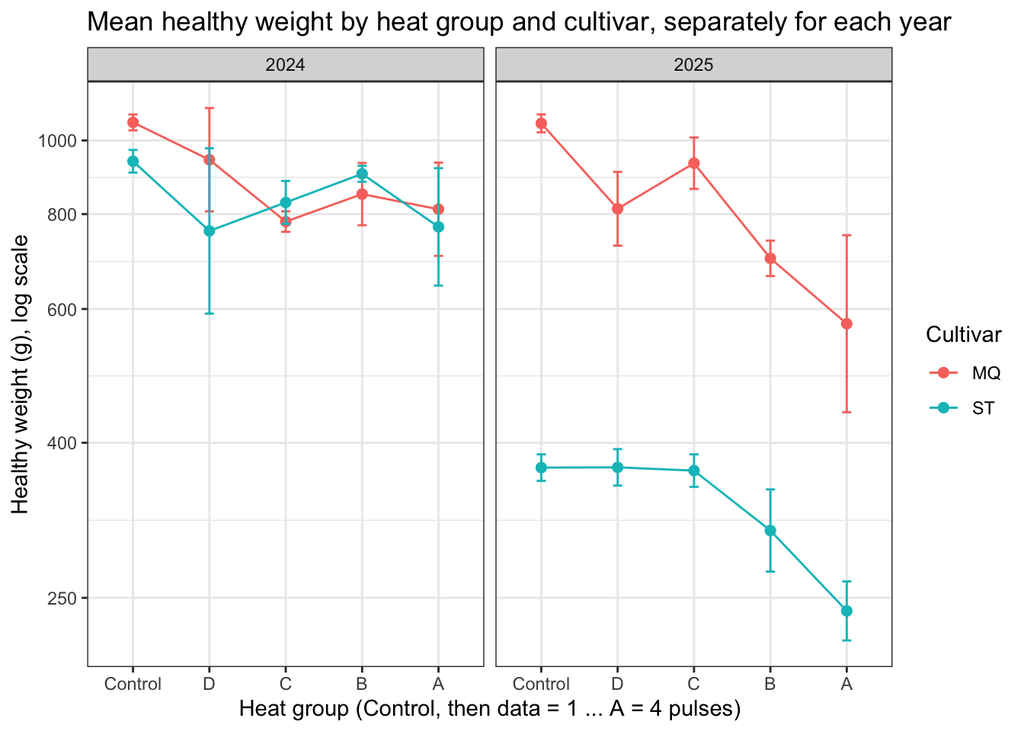

There may be a potential heat group and year interaction.

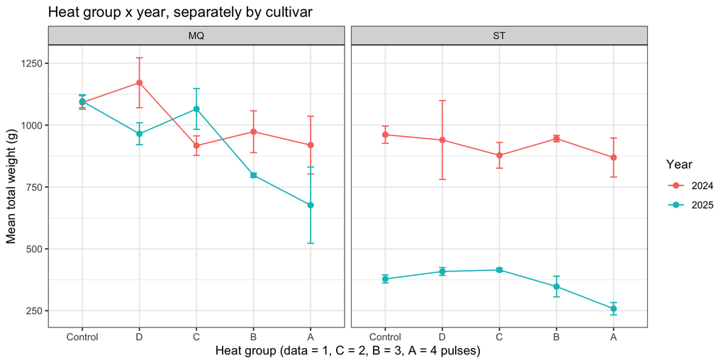

Mean total weight by heat group and year, separately for each cultivar. The 2024 and 2025 profiles differ: 2025 is lower overall, and MQ declines sharply at B/A in 2025 while ST is flatter. This supports a heat_group x year interaction.

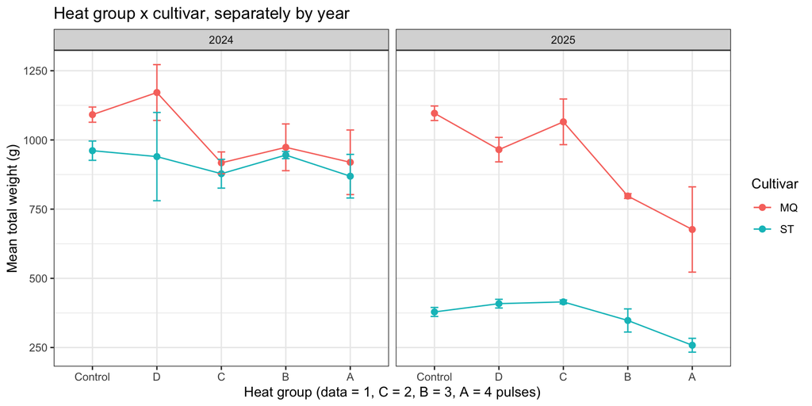

Mean total weight by heat group and cultivar, separately by year. MQ and ST differ mainly in level; their heat profiles are similar enough that a heat_group x cultivar interaction is not obviously required, but it is tested in H1.

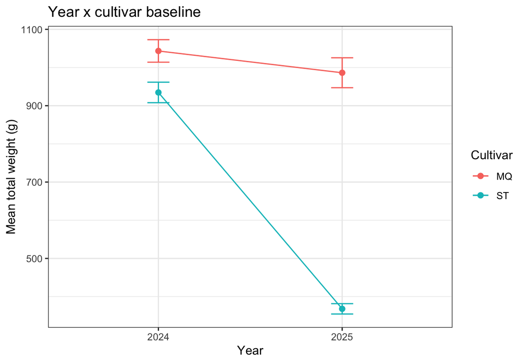

Mean total weight by year and cultivar. The large 2025 ST drop supports a year x cultivar baseline term.

The figures support the following model structure:

- **log(total_weight)** rather than raw weight: the response is positive, the effects are naturally multiplicative, and the log-scale residuals are more homogeneous.
- **(1 | pair_id)**: control and heat plots in the same pair_id are strongly correlated, so the pair_id must be a random effect.
- **heat_group × year**: the 2024 and 2025 profiles have different shapes, especially for MQ; ST is much lower in 2025.
- **year:cultivar**: 2025 ST is much lower than 2024 ST, a baseline shift that is not a heat effect.
- **heat_group × cultivar**: MQ and ST differ mainly in level; their heat profiles are similar enough that the interaction is tested but not obviously required.

The model-building section below fits the candidate models H0–H4 and compares them with AIC and likelihood-ratio tests.

pair_id structure

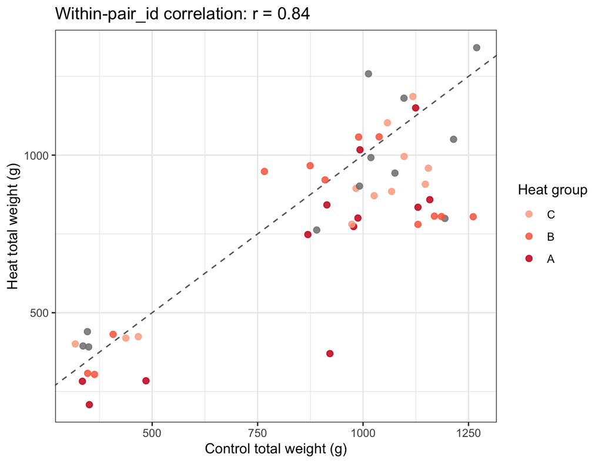

Control and heat total weights within the same pair_id are strongly correlated (r = 0.84). This supports the pair_id random intercept (1 | pair_id).

Because r=0.84 represents a strong positive correlation, plants in the same pair tend to naturally start or grow at similar sizes (likely due to shared microclimate, soil, or location). Model Justification: This high correlation proves that observations within a pair are not independent. Mixed Model Syntax: It validates using a mixed-effects model with a random intercept for pairs - lmer(total_weight ~ heat_group + (1 | pair_id))—to control for pair-level baseline differences and avoid artificially inflated sample sizes/p-values.

## 4) How does heat stress affect yield as measured by the total weight of fruit?

### 4.1 Candidate models

Total fruit weight is positive and right-skewed, so we model `log(total_weight)`. The candidate fixed-effect structures are:

```r
fit_lmm <- function(form) lmer(form, data = data, REML = FALSE)

h0_total <- fit_lmm(log(total_weight) ~ heat_group + cultivar + year + year:cultivar + (1 | pair_id))

h1_total <- fit_lmm(log(total_weight) ~ heat_group * cultivar + year + year:cultivar + (1 | pair_id))

h2_total <- fit_lmm(log(total_weight) ~ heat_group * year + cultivar + year:cultivar + (1 | pair_id))

h3_total <- fit_lmm(log(total_weight) ~ heat_group * (cultivar + year) + year:cultivar + (1 | pair_id))

h4_total <- fit_lmm(log(total_weight) ~ treatment * intensity_group + cultivar + year + year:cultivar + (1 | pair_id))
```

```r
models_total <- list(
  H0 = h0_total,
  H1 = h1_total,
  H2 = h2_total,
  H3 = h3_total,
  H4 = h4_total
)

aic_tab <- data.frame(
  Model = names(models_total),
  df    = sapply(models_total, function(m) attr(logLik(m), "df")),
  AIC   = sapply(models_total, AIC)
) %>%
  mutate(dAIC = AIC - min(AIC))

kable(aic_tab, digits = 2, row.names = FALSE,
      caption = "AIC comparison for total weight (ML fits).")
```

AIC comparison for total weight (ML fits).

| Model | df | AIC | dAIC |
| --- | --- | --- | --- |
| H0 | 10 | -71.59 | 13.01 |
| H1 | 14 | -68.64 | 15.96 |
| H2 | 14 | -84.60 | 0.00 |
| H3 | 18 | -83.69 | 0.91 |
| H4 | 13 | -66.65 | 17.95 |

H2 has the smallest AIC, so we select H2.

### 4.2 Heteroscedastic residual variance

H2 assumes a common residual variance. Control and heat plots may differ in their residual spread, so we refit the same fixed and random effects with `nlme::lme` and allow a separate residual variance for Control and OTC:

```r
h2_lmm <- lmer(log(total_weight) ~ heat_group * year + cultivar + year:cultivar +
                 (1 | pair_id), data = data, REML = TRUE)



h2_hom <- lme(log(total_weight) ~ heat_group * year + cultivar + year:cultivar,
              random = ~ 1 | pair_id, data = data, method = "REML")
h2_het <- update(h2_hom, weights = varIdent(form = ~ 1 | treatment))

anova(h2_hom, h2_het)
```

```
##        Model df       AIC       BIC   logLik   Test  L.Ratio p-value
## h2_hom     1 14 -33.91285  0.118586 30.95642
## h2_het     2 15 -39.92700 -3.464752 34.96350 1 vs 2 8.014156  0.0046
```

The likelihood-ratio test is significant, so the model with separate residual variances is preferred. We use `h2_het` for the final estimates.

### 4.3 Coefficients of the final model

```r
coef_tab <- summary(h2_het)$tTable
coef_ci  <- intervals(h2_het, which = "fixed")$fixed

data.frame(
  Term       = rownames(coef_tab),
  Estimate   = coef_tab[, "Value"],
  SE         = coef_tab[, "Std.Error"],
  p_value    = format.pval(coef_tab[, "p-value"], digits = 3, eps = 1e-4),
  Ratio      = exp(coef_tab[, "Value"]),
  Lower_95   = exp(coef_ci[, "lower"]),
  Upper_95   = exp(coef_ci[, "upper"]),
  row.names  = NULL
) %>%
  kable(digits = 3,
        caption = "Fixed-effect estimates of the final heteroscedastic H2 model.")
```

Fixed-effect estimates of the final heteroscedastic H2 model.

| Term | Estimate | SE | p_value | Ratio | Lower_95 | Upper_95 |
| --- | --- | --- | --- | --- | --- | --- |
| (Intercept) | 6.987 | 0.031 | < 1e-04 | 1082.535 | 1016.681 | 1152.654 |
| heat_groupD | -0.006 | 0.072 | 0.93396 | 0.994 | 0.859 | 1.150 |
| heat_groupC | -0.140 | 0.072 | 0.05976 | 0.870 | 0.752 | 1.006 |
| heat_groupB | -0.044 | 0.072 | 0.54507 | 0.957 | 0.827 | 1.107 |
| heat_groupA | -0.135 | 0.072 | 0.06883 | 0.874 | 0.755 | 1.011 |
| year2025 | -0.012 | 0.044 | 0.79197 | 0.988 | 0.904 | 1.080 |
| cultivarST | -0.121 | 0.042 | 0.00636 | 0.886 | 0.814 | 0.965 |
| heat_groupD:year2025 | 0.001 | 0.102 | 0.99550 | 1.001 | 0.814 | 1.230 |
| heat_groupC:year2025 | 0.160 | 0.102 | 0.12503 | 1.173 | 0.955 | 1.442 |
| heat_groupB:year2025 | -0.167 | 0.102 | 0.10883 | 0.846 | 0.688 | 1.040 |
| heat_groupA:year2025 | -0.321 | 0.102 | 0.00311 | 0.725 | 0.590 | 0.891 |
| year2025:cultivarST | -0.906 | 0.060 | < 1e-04 | 0.404 | 0.358 | 0.456 |

The reference levels are Control, 2024 and MQ. The `heat_group` coefficients are log ratios relative to Control in 2024 for MQ; the `:year2025` terms add the extra change in 2025; `cultivarST` is the ST/MQ baseline difference in 2024; `year2025:cultivarST` is the extra 2025 change for ST.

### 4.4 Answer

# 5) How does heat stress affect yield as measured by the total weight of healthy fruit?

```r
# Part 6: model comparison
fit_lmm <- function(form) lmer(form, data = data, REML = FALSE)

# no heat effect at all (baseline: cultivar x year only)
h_noheat <- fit_lmm(log(healthy_weight) ~ cultivar * year + (1 | pair_id))
# heat effect is the same in every cultivar-year
h0 <- fit_lmm(log(healthy_weight) ~ heat_group + cultivar + year + year:cultivar + (1 | pair_id))
# heat effect depends on cultivar
h1 <- fit_lmm(log(healthy_weight) ~ heat_group * cultivar + year + year:cultivar + (1 | pair_id))
# heat effect depends on year
h2 <- fit_lmm(log(healthy_weight) ~ heat_group * year + cultivar + year:cultivar + (1 | pair_id))
# heat effect depends on cultivar and on year, but no three-way interaction
h3 <- fit_lmm(log(healthy_weight) ~ heat_group * (cultivar + year) + year:cultivar + (1 | pair_id))
# full model: heat effect can differ in every cultivar-year
h_full <- fit_lmm(log(healthy_weight) ~ heat_group * cultivar * year + (1 | pair_id))

models <- list(h_noheat = h_noheat, h0 = h0, h1 = h1, h2 = h2, h3 = h3, h_full = h_full)
```

```r
# AIC / BIC table
aic_tab <- data.frame(
  model = names(models),
  df    = sapply(models, function(m) attr(logLik(m), "df")),
  AIC   = sapply(models, AIC),
  BIC   = sapply(models, BIC)
) %>%
  mutate(dAIC = AIC - min(AIC), dBIC = BIC - min(BIC))
print(aic_tab, row.names = FALSE)
```

```
##     model df       AIC        BIC      dAIC      dBIC
##  h_noheat  6 -11.79739   3.588698 41.368894 24.799416
##        h0 10 -46.85420 -21.210718  6.312084  0.000000
##        h1 14 -43.82379  -7.922919  9.342491 13.287799
##        h2 14 -53.16628 -17.265410  0.000000  3.945308
##        h3 18 -51.44726  -5.288989  1.719028 15.921729
##    h_full 22 -48.10952   8.306136  5.056760 29.516854
```

```r
# Likelihood-ratio tests between nested models
anova(h_noheat, h0)   # is there any heat effect?
```

```
## Data: data
## Models:
## h_noheat: log(healthy_weight) ~ cultivar * year + (1 | pair_id)
## h0: log(healthy_weight) ~ heat_group + cultivar + year + year:cultivar + (1 | pair_id)
##          npar     AIC      BIC logLik -2*log(L)  Chisq Df Pr(>Chisq)
## h_noheat    6 -11.797   3.5887 11.899   -23.797
## h0         10 -46.854 -21.2107 33.427   -66.854 43.057  4  1.007e-08 ***
## ---
## Signif. codes:  0 '***' 0.001 '**' 0.01 '*' 0.05 '.' 0.1 ' ' 1
```

```r
anova(h0, h1)         # does the heat effect depend on cultivar?
```

```
## Data: data
## Models:
## h0: log(healthy_weight) ~ heat_group + cultivar + year + year:cultivar + (1 | pair_id)
## h1: log(healthy_weight) ~ heat_group * cultivar + year + year:cultivar + (1 | pair_id)
##    npar     AIC      BIC logLik -2*log(L)  Chisq Df Pr(>Chisq)
## h0   10 -46.854 -21.2107 33.427   -66.854
## h1   14 -43.824  -7.9229 35.912   -71.824 4.9696  4     0.2904
```

```r
anova(h0, h2)         # does the heat effect depend on year?
```

```
## Data: data
## Models:
## h0: log(healthy_weight) ~ heat_group + cultivar + year + year:cultivar + (1 | pair_id)
## h2: log(healthy_weight) ~ heat_group * year + cultivar + year:cultivar + (1 | pair_id)
##    npar     AIC     BIC logLik -2*log(L)  Chisq Df Pr(>Chisq)
## h0   10 -46.854 -21.211 33.427   -66.854
## h2   14 -53.166 -17.265 40.583   -81.166 14.312  4   0.006363 **
## ---
## Signif. codes:  0 '***' 0.001 '**' 0.01 '*' 0.05 '.' 0.1 ' ' 1
```

```r
anova(h1, h3)         # adding heat x year after heat x cultivar
```

```
## Data: data
## Models:
## h1: log(healthy_weight) ~ heat_group * cultivar + year + year:cultivar + (1 | pair_id)
## h3: log(healthy_weight) ~ heat_group * (cultivar + year) + year:cultivar + (1 | pair_id)
##    npar     AIC     BIC logLik -2*log(L)  Chisq Df Pr(>Chisq)
## h1   14 -43.824 -7.9229 35.912   -71.824
## h3   18 -51.447 -5.2890 43.724   -87.447 15.623  4   0.003568 **
## ---
## Signif. codes:  0 '***' 0.001 '**' 0.01 '*' 0.05 '.' 0.1 ' ' 1
```

```r
anova(h2, h3)         # adding heat x cultivar after heat x year
```

```
## Data: data
## Models:
## h2: log(healthy_weight) ~ heat_group * year + cultivar + year:cultivar + (1 | pair_id)
## h3: log(healthy_weight) ~ heat_group * (cultivar + year) + year:cultivar + (1 | pair_id)
##    npar     AIC     BIC logLik -2*log(L) Chisq Df Pr(>Chisq)
## h2   14 -53.166 -17.265 40.583   -81.166
## h3   18 -51.447  -5.289 43.724   -87.447 6.281  4     0.1791
```

```r
anova(h3, h_full)     # three-way interaction
```

```
## Data: data
## Models:
## h3: log(healthy_weight) ~ heat_group * (cultivar + year) + year:cultivar + (1 | pair_id)
## h_full: log(healthy_weight) ~ heat_group * cultivar * year + (1 | pair_id)
##        npar     AIC     BIC logLik -2*log(L)  Chisq Df Pr(>Chisq)
## h3       18 -51.447 -5.2890 43.724   -87.447
## h_full   22 -48.110  8.3061 46.055   -92.110 4.6623  4     0.3237
```

```r
sapply(models, isSingular)   # TRUE = pair_id variance estimated as ~0
```

```
## h_noheat       h0       h1       h2       h3   h_full
##     TRUE    FALSE    FALSE    FALSE    FALSE    FALSE
```

```r
# Part 7: Equal-variance model and diagnostics
h2_lmm <- lmer(log(healthy_weight) ~ heat_group * year + cultivar + year:cultivar +
                   (1 | pair_id), data = data, REML = TRUE)
isSingular(h2_lmm)
```

```
## [1] FALSE
```

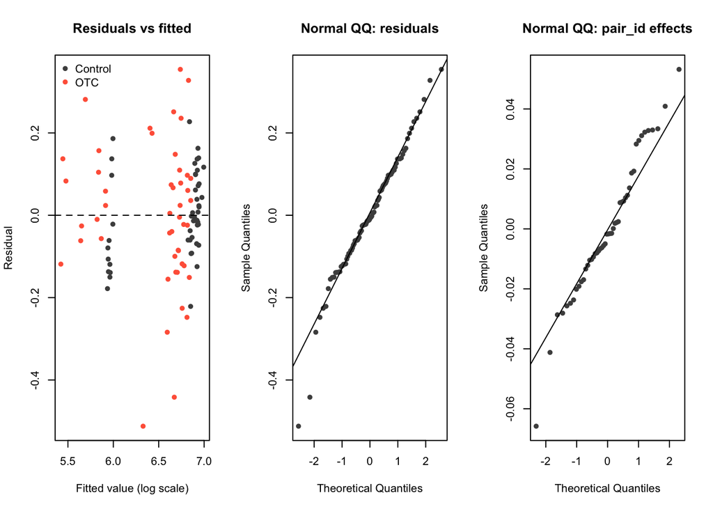

```r
# Residual diagnostics for the equal-variance model
par(mfrow = c(1, 3))

# Residuals vs fitted values, coloured by treatment
plot(fitted(h2_lmm), resid(h2_lmm),
     col = ifelse(data$treatment == "OTC", "tomato", "grey30"), pch = 16,
     xlab = "Fitted value (log scale)", ylab = "Residual",
     main = "Residuals vs fitted")
abline(h = 0, lty = 2)
legend("topleft", legend = c("Control", "OTC"),
       col = c("grey30", "tomato"), pch = 16, bty = "n")

# Normal QQ plot of the residuals
qqnorm(resid(h2_lmm), main = "Normal QQ: residuals", pch = 16, col = "grey30")
qqline(resid(h2_lmm))

# Normal QQ plot of the estimated pair_id effects
re_pair <- ranef(h2_lmm)$pair_id[, 1]
qqnorm(re_pair, main = "Normal QQ: pair_id effects", pch = 16, col = "grey30")
qqline(re_pair)
```

```r
par(mfrow = c(1, 1))

# Residual SD by treatment
data %>%
  mutate(r = resid(h2_lmm)) %>%
  group_by(treatment) %>%
  summarise(sd_resid = sd(r))
```

```
## # A tibble: 2 × 2
##   treatment sd_resid
##   <fct>        <dbl>
## 1 Control      0.102
## 2 OTC          0.177
```

```r
# Part 8: Model with separate residual variances for Control and OTC
library(nlme)

# Same fixed and random effects as h2_lmm, refitted with nlme
h2_hom <- lme(log(healthy_weight) ~ heat_group * year + cultivar + year:cultivar,
              random = ~ 1 | pair_id, data = data, method = "REML")

# Control and OTC plots have separate residual variances
h2_het <- update(h2_hom, weights = varIdent(form = ~ 1 | treatment))

# Likelihood-ratio test for unequal residual variances
anova(h2_hom, h2_het)
```

```
##        Model df        AIC      BIC   logLik   Test  L.Ratio p-value
## h2_hom     1 14  -6.312392 27.71904 17.15620
## h2_het     2 15 -21.930513 14.53174 25.96526 1 vs 2 17.61812  <.0001
```

```r
# Estimated residual SD of Control, and ratio OTC SD / Control SD
sigma(h2_het)
```

```
## [1] 0.09273427
```

```r
coef(h2_het$modelStruct$varStruct, unconstrained = FALSE)
```

```
##      OTC
## 2.288368
```

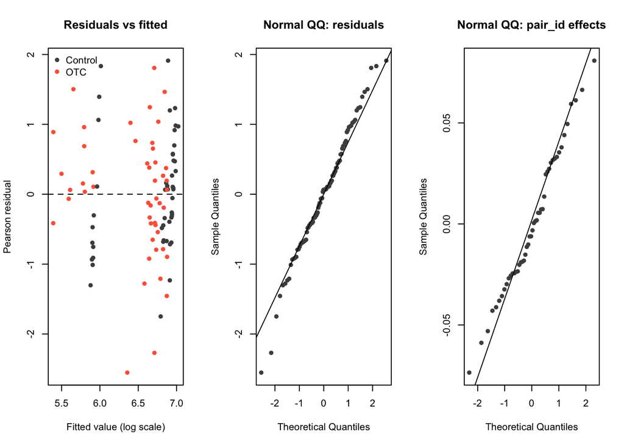

```r
# Diagnostics of the unequal-variance model, using Pearson residuals
r_pear <- resid(h2_het, type = "pearson")

par(mfrow = c(1, 3))
plot(fitted(h2_het), r_pear,
     col = ifelse(data$treatment == "OTC", "tomato", "grey30"), pch = 16,
     xlab = "Fitted value (log scale)", ylab = "Pearson residual",
     main = "Residuals vs fitted")
abline(h = 0, lty = 2)
legend("topleft", legend = c("Control", "OTC"),
       col = c("grey30", "tomato"), pch = 16, bty = "n")

qqnorm(r_pear, main = "Normal QQ: residuals", pch = 16, col = "grey30")
qqline(r_pear)

re_pair <- ranef(h2_het)[, 1]
qqnorm(re_pair, main = "Normal QQ: pair_id effects", pch = 16, col = "grey30")
qqline(re_pair)
```

```r
par(mfrow = c(1, 1))

# Pearson residual SD by treatment
data %>%
  mutate(r = r_pear) %>%
  group_by(treatment) %>%
  summarise(sd_resid = sd(r))
```

```
## # A tibble: 2 × 2
##   treatment sd_resid
##   <fct>        <dbl>
## 1 Control      0.818
## 2 OTC          0.894
```

```r
# Part 9: Final model
h2_final <- h2_het
```

$$\log Y_i = \mu + \alpha_{g_i} + \beta_{t_i} + (\alpha\beta)_{g_i t_i}
+ \gamma_{c_i} + (\beta\gamma)_{t_i c_i} + b_{k(i)} + \varepsilon_i,$$
$$b_k \sim N(0, \sigma_b^2), \qquad
\varepsilon_i \sim N\!\left(0, \sigma^2_{\text{trt}(i)}\right), \quad
\text{trt}(i) \in \{\text{Control}, \text{OTC}\},$$

```r
# Coefficients of the final model
coef_tab <- summary(h2_final)$tTable
coef_ci  <- intervals(h2_final, which = "fixed")$fixed

data.frame(term     = rownames(coef_tab),
           estimate = coef_tab[, "Value"],
           SE       = coef_tab[, "Std.Error"],
           df       = coef_tab[, "DF"],
           p        = coef_tab[, "p-value"],
           ratio    = exp(coef_tab[, "Value"]),
           lower_95 = exp(coef_ci[, "lower"]),
           upper_95 = exp(coef_ci[, "upper"]),
           row.names = NULL) %>%
  kable(digits = 3)
```

| term | estimate | SE | df | p | ratio | lower_95 | upper_95 |
| --- | --- | --- | --- | --- | --- | --- | --- |
| (Intercept) | 6.956 | 0.031 | 44 | 0.000 | 1049.562 | 985.466 | 1117.826 |
| heat_groupD | -0.178 | 0.091 | 40 | 0.057 | 0.837 | 0.697 | 1.005 |
| heat_groupC | -0.221 | 0.091 | 40 | 0.019 | 0.802 | 0.668 | 0.963 |
| heat_groupB | -0.108 | 0.091 | 40 | 0.239 | 0.897 | 0.747 | 1.078 |
| heat_groupA | -0.227 | 0.091 | 40 | 0.016 | 0.797 | 0.664 | 0.957 |
| year2025 | -0.012 | 0.044 | 44 | 0.791 | 0.988 | 0.904 | 1.080 |
| cultivarST | -0.105 | 0.043 | 44 | 0.018 | 0.900 | 0.826 | 0.982 |
| heat_groupD:year2025 | 0.061 | 0.128 | 40 | 0.638 | 1.063 | 0.820 | 1.376 |
| heat_groupC:year2025 | 0.146 | 0.128 | 40 | 0.262 | 1.157 | 0.893 | 1.498 |
| heat_groupB:year2025 | -0.201 | 0.128 | 40 | 0.125 | 0.818 | 0.632 | 1.060 |
| heat_groupA:year2025 | -0.287 | 0.128 | 40 | 0.031 | 0.751 | 0.580 | 0.973 |
| year2025:cultivarST | -0.908 | 0.061 | 44 | 0.000 | 0.403 | 0.357 | 0.456 |

```r
# Variance components of the final model
vc <- VarCorr(h2_final)
sd_pair <- as.numeric(vc["(Intercept)", "StdDev"])
sd_ctrl <- sigma(h2_final)
sd_otc  <- sd_ctrl * coef(h2_final$modelStruct$varStruct, unconstrained = FALSE)[1]

# Correlation between the Control and OTC plot of the same pair_id
icc <- sd_pair^2 / sqrt((sd_pair^2 + sd_ctrl^2) * (sd_pair^2 + sd_otc^2))

data.frame(component = c("pair_id SD", "residual SD (Control)", "residual SD (OTC)",
                         "within-pair_id correlation"),
           value = c(sd_pair, sd_ctrl, sd_otc, icc))
```

```
##                    component      value
## 1                 pair_id SD 0.06181218
## 2      residual SD (Control) 0.09273427
## 3          residual SD (OTC) 0.21221011
## 4 within-pair_id correlation 0.15510685
```

```r
# Part 10: Tests and contrasts
joint_tests(h2_final)
```

```
##  model term      df1 df2 F.ratio p.value
##  heat_group        4  40  12.770 <0.0001
##  year              1  40  99.109 <0.0001
##  cultivar          1  44 339.531 <0.0001
##  heat_group:year   4  40   2.281  0.0774
##  year:cultivar     1  44 223.980 <0.0001
```

```r
emm_h <- emmeans(h2_final, ~ heat_group | year)
```

```r
# Each intensity vs Control within each year, Dunnett-adjusted, as ratios OTC / Control
ct <- contrast(emm_h, "trt.vs.ctrl", ref = "Control")
summary(ct, type = "response", infer = TRUE)
```

```
## year = 2024:
##  contrast    ratio     SE df lower.CL upper.CL null t.ratio p.value
##  D / Control 0.837 0.0758 40    0.664    1.055    1  -1.963  0.1764
##  C / Control 0.802 0.0726 40    0.636    1.011    1  -2.440  0.0654
##  B / Control 0.897 0.0812 40    0.712    1.131    1  -1.196  0.5654
##  A / Control 0.797 0.0721 40    0.632    1.005    1  -2.506  0.0562
##
## year = 2025:
##  contrast    ratio     SE df lower.CL upper.CL null t.ratio p.value
##  D / Control 0.890 0.0805 40    0.706    1.121    1  -1.293  0.5048
##  C / Control 0.927 0.0840 40    0.736    1.169    1  -0.832  0.7854
##  B / Control 0.734 0.0665 40    0.583    0.926    1  -3.412  0.0055
##  A / Control 0.598 0.0542 40    0.475    0.754    1  -5.672 <0.0001
##
## Results are averaged over the levels of: cultivar
## Degrees-of-freedom method: containment
## Confidence level used: 0.95
## Conf-level adjustment: dunnettx method for 4 estimates
## Intervals are back-transformed from the log scale
## P value adjustment: dunnettx method for 4 tests
## Tests are performed on the log scale
```

```r
# Average OTC effect over the four intensities within each year
ct_avg <- contrast(emm_h, list("OTC avg vs Control" = c(-1, 1/4, 1/4, 1/4, 1/4)))
summary(ct_avg, type = "response", infer = TRUE)
```

```
## year = 2024:
##  contrast           ratio     SE df lower.CL upper.CL null t.ratio p.value
##  OTC avg vs Control 0.832 0.0394 40    0.757    0.916    1  -3.880  0.0004
##
## year = 2025:
##  contrast           ratio     SE df lower.CL upper.CL null t.ratio p.value
##  OTC avg vs Control 0.776 0.0367 40    0.705    0.854    1  -5.366 <0.0001
##
## Results are averaged over the levels of: cultivar
## Degrees-of-freedom method: containment
## Confidence level used: 0.95
## Intervals are back-transformed from the log scale
## Tests are performed on the log scale
```

```r
# Dose response among the four OTC intensities within each year
emm_otc <- emmeans(h2_final, ~ heat_group | year,
                   at = list(heat_group = c("D", "C", "B", "A")))
contrast(emm_otc, "poly")
```

```
## year = 2024:
##  contrast  estimate    SE df t.ratio p.value
##  linear     -0.0350 0.399 40  -0.088  0.9305
##  quadratic  -0.0755 0.178 40  -0.423  0.6744
##  cubic      -0.3871 0.399 40  -0.971  0.3374
##
## year = 2025:
##  contrast  estimate    SE df t.ratio p.value
##  linear     -1.4227 0.399 40  -3.569  0.0009
##  quadratic  -0.2463 0.178 40  -1.381  0.1748
##  cubic       0.3043 0.399 40   0.763  0.4498
##
## Results are averaged over the levels of: cultivar
## Degrees-of-freedom method: containment
## Results are given on the log (not the response) scale.
```

```r
# Multiplicative change in healthy weight per additional heat pulse
slope <- contrast(emm_otc, list("per extra pulse" = c(-3, -1, 1, 3) / 10))
summary(slope, type = "response", infer = TRUE)
```

```
## year = 2024:
##  contrast        ratio     SE df lower.CL upper.CL null t.ratio p.value
##  per extra pulse 0.997 0.0397 40    0.919     1.08    1  -0.088  0.9305
##
## year = 2025:
##  contrast        ratio     SE df lower.CL upper.CL null t.ratio p.value
##  per extra pulse 0.867 0.0346 40    0.800     0.94    1  -3.569  0.0009
##
## Results are averaged over the levels of: cultivar
## Degrees-of-freedom method: containment
## Confidence level used: 0.95
## Intervals are back-transformed from the log scale
## Tests are performed on the log scale
```

```r
# Difference in the dose-response slope between years (exploratory)
pairs(slope, by = NULL)
```

```
##  contrast                                            estimate     SE df t.ratio
##  per extra pulse year2024 - per extra pulse year2025    0.139 0.0564 40   2.461
##  p.value
##   0.0182
##
## Results are averaged over the levels of: cultivar
## Degrees-of-freedom method: containment
## Results are given on the log (not the response) scale.
```

```r
# Average OTC effect over both years
emm_all <- emmeans(h2_final, ~ heat_group)
summary(contrast(emm_all, list("OTC avg vs Control" = c(-1, 1/4, 1/4, 1/4, 1/4))),
        type = "response", infer = TRUE)
```

```
##  contrast           ratio     SE df lower.CL upper.CL null t.ratio p.value
##  OTC avg vs Control 0.804 0.0269 40    0.751     0.86    1  -6.538 <0.0001
##
## Results are averaged over the levels of: year, cultivar
## Degrees-of-freedom method: containment
## Confidence level used: 0.95
## Intervals are back-transformed from the log scale
## Tests are performed on the log scale
```

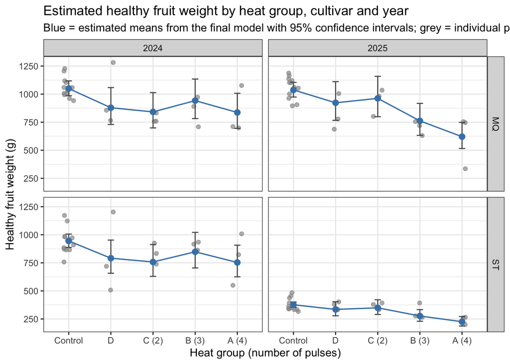

```r
# Part 11: model estimates
emm_cell <- emmeans(h2_final, ~ heat_group | year * cultivar)
est <- as.data.frame(summary(emm_cell, type = "response"))   # response, lower.CL, upper.CL in grams

ggplot() +
  geom_jitter(data = data, aes(x = heat_group, y = healthy_weight),
              width = 0.12, colour = "grey60", alpha = 0.7, size = 1.6) +
  geom_errorbar(data = est, aes(x = heat_group, ymin = lower.CL, ymax = upper.CL),
                width = 0.15, colour = "grey35") +
  geom_line(data = est, aes(x = heat_group, y = response, group = 1),
            colour = "steelblue", linewidth = 0.6) +
  geom_point(data = est, aes(x = heat_group, y = response),
             colour = "steelblue", size = 2.4) +
  facet_grid(cultivar ~ year) +
  scale_x_discrete(labels = c(Control = "Control", data = "data (1)", C = "C (2)",
                              B = "B (3)", A = "A (4)")) +
  labs(x = "Heat group (number of pulses)",
       y = "Healthy fruit weight (g)",
       title = "Estimated healthy fruit weight by heat group, cultivar and year",
       subtitle = "Blue = estimated means from the final model with 95% confidence intervals; grey = individual plots") +
  theme_bw(base_size = 11)
```

```r
# Part 12: Sensitivity to the most extreme plots
# Pearson residuals put Control and OTC plots on the same scale
data$r <- resid(h2_final, type = "pearson")
data %>%
  arrange(desc(abs(r))) %>%
  select(pair_id, year, cultivar, heat_group, healthy_weight, r) %>%
  head(6)
```

```
##       pair_id year cultivar heat_group healthy_weight         r
## 1 2025.MQ.A.2 2025       MQ          A         335.50 -2.552697
## 2 2024.ST.D.1 2024       ST          D         507.62 -2.269694
## 3 2024.ST.D.1 2024       ST    Control        1171.88  1.911880
## 4 2025.ST.A.1 2025       ST    Control         484.11  1.833762
## 5 2024.ST.D.3 2024       ST          D        1202.90  1.807666
## 6 2024.ST.B.1 2024       ST    Control         757.58 -1.749084
```

```r
# The whole pairs of the 3 largest residuals are removed and the model is refitted
out_pairs <- data %>% arrange(desc(abs(r))) %>% slice(1:3) %>%
  pull(pair_id) %>% as.character() %>% unique()
d_sub <- data %>% filter(!pair_id %in% out_pairs) %>% droplevels()

h2_sub <- update(h2_final, data = d_sub)

emm_sub <- emmeans(h2_sub, ~ heat_group | year)
summary(contrast(emm_sub, "trt.vs.ctrl", ref = "Control"), type = "response", infer = TRUE)
```

```
## year = 2024:
##  contrast    ratio     SE df lower.CL upper.CL null t.ratio p.value
##  D / Control 0.931 0.0756 38    0.756    1.146    1  -0.881  0.7584
##  C / Control 0.805 0.0598 38    0.665    0.974    1  -2.921  0.0210
##  B / Control 0.907 0.0674 38    0.750    1.097    1  -1.313  0.4930
##  A / Control 0.803 0.0596 38    0.663    0.971    1  -2.961  0.0190
##
## year = 2025:
##  contrast    ratio     SE df lower.CL upper.CL null t.ratio p.value
##  D / Control 0.889 0.0660 38    0.735    1.075    1  -1.587  0.3373
##  C / Control 0.921 0.0685 38    0.762    1.115    1  -1.100  0.6258
##  B / Control 0.730 0.0542 38    0.603    0.883    1  -4.238  0.0005
##  A / Control 0.669 0.0544 38    0.544    0.824    1  -4.944 <0.0001
##
## Results are averaged over the levels of: cultivar
## Degrees-of-freedom method: containment
## Confidence level used: 0.95
## Conf-level adjustment: dunnettx method for 4 estimates
## Intervals are back-transformed from the log scale
## P value adjustment: dunnettx method for 4 tests
## Tests are performed on the log scale
```

```r
summary(contrast(emm_sub, list("OTC avg vs Control" = c(-1, 1/4, 1/4, 1/4, 1/4))),
        type = "response", infer = TRUE)
```

```
## year = 2024:
##  contrast           ratio     SE df lower.CL upper.CL null t.ratio p.value
##  OTC avg vs Control 0.859 0.0342 38    0.793    0.932    1  -3.806  0.0005
##
## year = 2025:
##  contrast           ratio     SE df lower.CL upper.CL null t.ratio p.value
##  OTC avg vs Control 0.795 0.0317 38    0.734    0.862    1  -5.751 <0.0001
##
## Results are averaged over the levels of: cultivar
## Degrees-of-freedom method: containment
## Confidence level used: 0.95
## Intervals are back-transformed from the log scale
## Tests are performed on the log scale
```

```r
emm_sub_otc <- emmeans(h2_sub, ~ heat_group | year,
                       at = list(heat_group = c("D", "C", "B", "A")))
summary(contrast(emm_sub_otc, list("per extra pulse" = c(-3, -1, 1, 3) / 10)),
        type = "response", infer = TRUE)
```

```
## year = 2024:
##  contrast        ratio     SE df lower.CL upper.CL null t.ratio p.value
##  per extra pulse 0.968 0.0330 38    0.903    1.037    1  -0.956  0.3453
##
## year = 2025:
##  contrast        ratio     SE df lower.CL upper.CL null t.ratio p.value
##  per extra pulse 0.897 0.0306 38    0.837    0.961    1  -3.177  0.0030
##
## Results are averaged over the levels of: cultivar
## Degrees-of-freedom method: containment
## Confidence level used: 0.95
## Intervals are back-transformed from the log scale
## Tests are performed on the log scale
```

## 6) How does heat stress affect yield as measured by the percentage of healthy berries by count?

First, we investigate the distribution of the healthy berries by count (n_healthy) variable

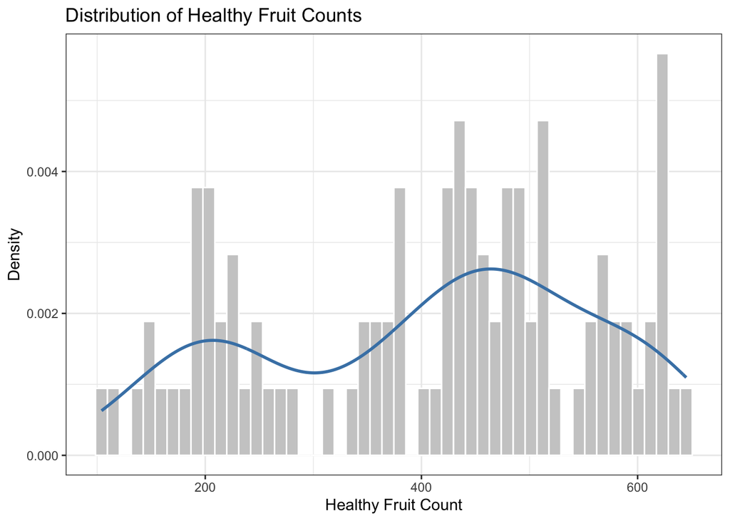

```r
ggplot(data, aes(x = healthy_n)) +
  geom_histogram(aes(y = after_stat(density)),
                 bins = 50, fill = "grey80", colour = "white") +
  geom_density(color = "steelblue", linewidth = 1) +
  labs(
    title = "Distribution of Healthy Fruit Counts",
    x = "Healthy Fruit Count",
    y = "Density"
  ) +
  theme_bw(base_size = 11)
```

Let’s look at interaction plot

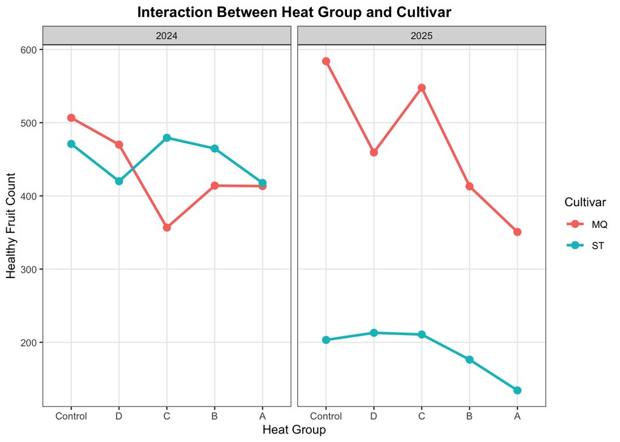

```r
ggplot(data, aes(x = factor(heat_group), y = healthy_n,
                 colour = cultivar, group = cultivar)) +
  stat_summary(fun = mean, geom = "line", linewidth = 1) +
  stat_summary(fun = mean, geom = "point", size = 2.5) +
  facet_wrap(~ year) +
  labs(
    title = "Interaction Between Heat Group and Cultivar",
    x = "Heat Group",
    y = "Healthy Fruit Count",
    colour = "Cultivar"
  ) +
  theme_bw(base_size = 10) +
  theme(
    plot.title = element_text(face = "bold", hjust = 0.5),
    panel.grid.minor = element_blank()
  )
```

- Note (Soren) : effect of heat group differ by culttivar
- Slopes differ across groups showing a possible heat group x cultivar interaction
- Patterns differ across - a possible heat group x culticar x year interaction

# Model Generation

```r
m1 <- glmmTMB(healthy_n ~ heat_group + cultivar + factor(year) + (1 | pair_id), family = nbinom2, data = data)
summary(m1)
```

```
##  Family: nbinom2  ( log )
## Formula:
## healthy_n ~ heat_group + cultivar + factor(year) + (1 | pair_id)
## Data: data
##
##       AIC       BIC    logLik -2*log(L)  df.resid
##    1175.9    1199.0    -579.0    1157.9        87
##
## Random effects:
##
## Conditional model:
##  Groups  Name        Variance Std.Dev.
##  pair_id (Intercept) 0.06198  0.249
## Number of obs: 96, groups:  pair_id, 48
##
## Dispersion parameter for nbinom2 family (): 32.9
##
## Conditional model:
##                  Estimate Std. Error z value Pr(>|z|)
## (Intercept)       6.45584    0.07261   88.91  < 2e-16 ***
## heat_groupD      -0.12947    0.06965   -1.86   0.0630 .
## heat_groupC      -0.11745    0.06949   -1.69   0.0910 .
## heat_groupB      -0.14598    0.07013   -2.08   0.0374 *
## heat_groupA      -0.30171    0.07041   -4.28 1.83e-05 ***
## cultivarST       -0.48475    0.08104   -5.98 2.21e-09 ***
## factor(year)2025 -0.38285    0.08105   -4.72 2.31e-06 ***
## ---
## Signif. codes:  0 '***' 0.001 '**' 0.01 '*' 0.05 '.' 0.1 ' ' 1
```

```r
m2 <- glmmTMB(healthy_n ~ heat_group * cultivar * factor(year) + (1 | pair_id), family = nbinom2, data = data)
summary(m2)
```

```
##  Family: nbinom2  ( log )
## Formula:
## healthy_n ~ heat_group * cultivar * factor(year) + (1 | pair_id)
## Data: data
##
##       AIC       BIC    logLik -2*log(L)  df.resid
##    1109.3    1165.7    -532.6    1065.3        74
##
## Random effects:
##
## Conditional model:
##  Groups  Name        Variance Std.Dev.
##  pair_id (Intercept) 0.006145 0.07839
## Number of obs: 96, groups:  pair_id, 48
##
## Dispersion parameter for nbinom2 family (): 52.4
##
## Conditional model:
##                                         Estimate Std. Error z value Pr(>|z|)
## (Intercept)                              6.22716    0.04765  130.69  < 2e-16
## heat_groupD                             -0.09040    0.10054   -0.90 0.368561
## heat_groupC                             -0.34390    0.10142   -3.39 0.000696
## heat_groupB                             -0.19746    0.10081   -1.96 0.050149
## heat_groupA                             -0.21340    0.10084   -2.12 0.034321
## cultivarST                              -0.07370    0.06751   -1.09 0.274944
## factor(year)2025                         0.14289    0.06722    2.13 0.033536
## heat_groupD:cultivarST                  -0.05899    0.14293   -0.41 0.679807
## heat_groupC:cultivarST                   0.33573    0.14394    2.33 0.019675
## heat_groupB:cultivarST                   0.21041    0.14331    1.47 0.142053
## heat_groupA:cultivarST                   0.11118    0.14420    0.77 0.440700
## heat_groupD:factor(year)2025            -0.15309    0.14180   -1.08 0.280319
## heat_groupC:factor(year)2025             0.27846    0.14220    1.96 0.050200
## heat_groupB:factor(year)2025            -0.16449    0.14283   -1.15 0.249458
## heat_groupA:factor(year)2025            -0.29541    0.14350   -2.06 0.039533
## cultivarST:factor(year)2025             -0.98768    0.09663  -10.22  < 2e-16
## heat_groupD:cultivarST:factor(year)2025  0.36382    0.20511    1.77 0.076103
## heat_groupC:cultivarST:factor(year)2025 -0.25160    0.20343   -1.24 0.216159
## heat_groupB:cultivarST:factor(year)2025  0.03539    0.20544    0.17 0.863220
## heat_groupA:cultivarST:factor(year)2025 -0.02577    0.20919   -0.12 0.901943
##
## (Intercept)                             ***
## heat_groupD
## heat_groupC                             ***
## heat_groupB                             .
## heat_groupA                             *
## cultivarST
## factor(year)2025                        *
## heat_groupD:cultivarST
## heat_groupC:cultivarST                  *
## heat_groupB:cultivarST
## heat_groupA:cultivarST
## heat_groupD:factor(year)2025
## heat_groupC:factor(year)2025            .
## heat_groupB:factor(year)2025
## heat_groupA:factor(year)2025            *
## cultivarST:factor(year)2025             ***
## heat_groupD:cultivarST:factor(year)2025 .
## heat_groupC:cultivarST:factor(year)2025
## heat_groupB:cultivarST:factor(year)2025
## heat_groupA:cultivarST:factor(year)2025
## ---
## Signif. codes:  0 '***' 0.001 '**' 0.01 '*' 0.05 '.' 0.1 ' ' 1
```

```r
anova(m1, m2)
```

```
## Data: data
## Models:
## m1: healthy_n ~ heat_group + cultivar + factor(year) + (1 | pair_id), zi=~0, disp=~1
## m2: healthy_n ~ heat_group * cultivar * factor(year) + (1 | pair_id), zi=~0, disp=~1
##    Df    AIC    BIC  logLik deviance  Chisq Chi Df Pr(>Chisq)
## m1  9 1175.9 1199.0 -578.95   1157.9
## m2 22 1109.3 1165.7 -532.65   1065.3 92.606     13  4.427e-14 ***
## ---
## Signif. codes:  0 '***' 0.001 '**' 0.01 '*' 0.05 '.' 0.1 ' ' 1
```

```r
# lets test further to test which interactions matter
m_add <- glmmTMB(healthy_n ~ heat_group + cultivar + factor(year) + (1 | pair_id), family = nbinom2, data = data)

m_2way <- glmmTMB(healthy_n ~ (heat_group + cultivar + factor(year))^2 +(1 | pair_id), family = nbinom2, data = data)
summary(m_2way)
```

```
##  Family: nbinom2  ( log )
## Formula:
## healthy_n ~ (heat_group + cultivar + factor(year))^2 + (1 | pair_id)
## Data: data
##
##       AIC       BIC    logLik -2*log(L)  df.resid
##    1106.5    1152.7    -535.3    1070.5        78
##
## Random effects:
##
## Conditional model:
##  Groups  Name        Variance Std.Dev.
##  pair_id (Intercept) 0.005143 0.07171
## Number of obs: 96, groups:  pair_id, 48
##
## Dispersion parameter for nbinom2 family (): 46.7
##
## Conditional model:
##                              Estimate Std. Error z value Pr(>|z|)
## (Intercept)                   6.23071    0.04637  134.38  < 2e-16 ***
## heat_groupD                  -0.17254    0.09086   -1.90  0.05757 .
## heat_groupC                  -0.28024    0.09230   -3.04  0.00239 **
## heat_groupB                  -0.20554    0.09113   -2.26  0.02411 *
## heat_groupA                  -0.20767    0.09155   -2.27  0.02330 *
## cultivarST                   -0.08041    0.06192   -1.30  0.19407
## factor(year)2025              0.13601    0.06174    2.20  0.02761 *
## heat_groupD:cultivarST        0.11981    0.10590    1.13  0.25791
## heat_groupC:cultivarST        0.21631    0.10692    2.02  0.04306 *
## heat_groupB:cultivarST        0.22081    0.10874    2.03  0.04228 *
## heat_groupA:cultivarST        0.09737    0.10740    0.91  0.36458
## heat_groupD:factor(year)2025  0.01824    0.10755    0.17  0.86536
## heat_groupC:factor(year)2025  0.15492    0.10561    1.47  0.14241
## heat_groupB:factor(year)2025 -0.14583    0.10646   -1.37  0.17072
## heat_groupA:factor(year)2025 -0.30638    0.10744   -2.85  0.00435 **
## cultivarST:factor(year)2025  -0.97237    0.07605  -12.79  < 2e-16 ***
## ---
## Signif. codes:  0 '***' 0.001 '**' 0.01 '*' 0.05 '.' 0.1 ' ' 1
```

```r
m_3way <- glmmTMB(healthy_n ~ heat_group * cultivar * factor(year) + (1 | pair_id), family = nbinom2, data = data)

anova(m_add, m_2way, m_3way)
```

```
## Data: data
## Models:
## m_add: healthy_n ~ heat_group + cultivar + factor(year) + (1 | pair_id), zi=~0, disp=~1
## m_2way: healthy_n ~ (heat_group + cultivar + factor(year))^2 + (1 | pair_id), zi=~0, disp=~1
## m_3way: healthy_n ~ heat_group * cultivar * factor(year) + (1 | pair_id), zi=~0, disp=~1
##        Df    AIC    BIC  logLik deviance   Chisq Chi Df Pr(>Chisq)
## m_add   9 1175.9 1199.0 -578.95   1157.9
## m_2way 18 1106.5 1152.7 -535.27   1070.5 87.3562      9  5.514e-15 ***
## m_3way 22 1109.3 1165.7 -532.65   1065.3  5.2497      4     0.2626
## ---
## Signif. codes:  0 '***' 0.001 '**' 0.01 '*' 0.05 '.' 0.1 ' ' 1
```

```r
#m1 <- glmmTMB(cbind(healthy_n, rotten_n) ~ heat_group + cultivar + factor(year) + (1 | pair_id), family = betabinomial(link = "logit"), data = data)
#summary(m1)
#m2 <- glmmTMB(cbind(healthy_n, rotten_n) ~ heat_group * cultivar + factor(year) + (1 | pair_id), family = betabinomial(link = "logit"), data = data)
#summary(m2)
#m3 <- glmmTMB(cbind(healthy_n, rotten_n) ~ heat_group + cultivar * factor(year) + (1 | pair_id), family = betabinomial(link = "logit"), data = data)
#summary(m3)

#anova(m2, m1, m3)
```

From the first anova, we show that there is strong evidence that the association between heat group and healthy fruit count depends on cultivar, year or their combination. But when we add a 2 way interaction model, we see that 2 way interaction model does way better.

– One important detail: because nbinom2 uses a log link, the coefficients are on the log expected-count scale. Exponentiating a coefficient gives a count ratio.

heat_groupD, pvalue ( 0.0576 ), About 15.8% fewer healthy fruits than Control; borderline evidence

percentages are calculated as (exp(beta) - 1 ) * 100

What the model concludes : Healthy fruit counts differ across several heat groups relative to Control. The heat-group effects for C and B differ between cultivars. The A-versus-Control effect differs between years. The cultivar difference changes substantially between years.

There is no statistically significant evidence that the full three-way interaction improves model fit ($p=0.263$, from your earlier comparison).

# TODO : look into this one more

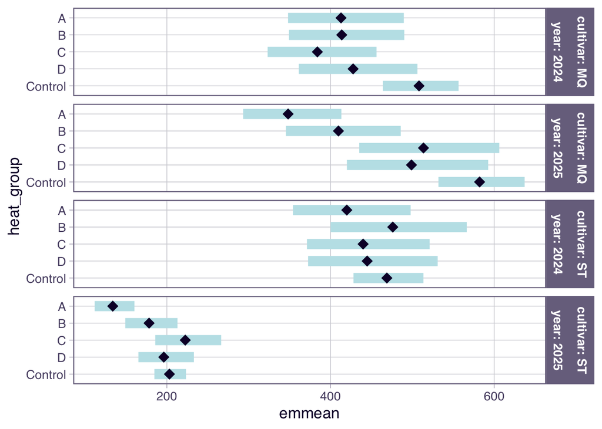

```r
m_final_emmeans <- emmeans(m_2way, ~ heat_group | cultivar * year, type = "response") # look into the model and then modify - heat_group | cultivar * year,

#m_final_emmeans <- emmeans(m_2way, pairwise ~ heat_group | cultivar * year,
#        type = "response",
#        adjust = "tukey")

plot(m_final_emmeans)
```

```r
contrast(
  m_final_emmeans,
  method = "trt.vs.ctrl",
  ref = 1,
  adjust = "dunnett",
  type = "response"
)
```

```
## cultivar = MQ, year = 2024:
##  contrast    ratio     SE  df null z.ratio p.value
##  D / Control 0.842 0.0765 Inf    1  -1.899  0.1817
##  C / Control 0.756 0.0697 Inf    1  -3.036  0.0090
##  B / Control 0.814 0.0742 Inf    1  -2.255  0.0824
##  A / Control 0.812 0.0744 Inf    1  -2.268  0.0798
##
## cultivar = ST, year = 2024:
##  contrast    ratio     SE  df null z.ratio p.value
##  D / Control 0.949 0.0893 Inf    1  -0.560  0.9105
##  C / Control 0.938 0.0852 Inf    1  -0.704  0.8497
##  B / Control 1.015 0.0952 Inf    1   0.163  0.9952
##  A / Control 0.896 0.0823 Inf    1  -1.201  0.5547
##
## cultivar = MQ, year = 2025:
##  contrast    ratio     SE  df null z.ratio p.value
##  D / Control 0.857 0.0789 Inf    1  -1.676  0.2768
##  C / Control 0.882 0.0788 Inf    1  -1.403  0.4272
##  B / Control 0.704 0.0642 Inf    1  -3.850  0.0005
##  A / Control 0.598 0.0551 Inf    1  -5.582 <0.0001
##
## cultivar = ST, year = 2025:
##  contrast    ratio     SE  df null z.ratio p.value
##  D / Control 0.966 0.0896 Inf    1  -0.372  0.9658
##  C / Control 1.095 0.1050 Inf    1   0.951  0.7139
##  B / Control 0.878 0.0843 Inf    1  -1.359  0.4538
##  A / Control 0.659 0.0635 Inf    1  -4.323 <0.0001
##
## P value adjustment: dunnettx method for 4 tests
## Tests are performed on the log scale
```

```r
res <- contrast(
  m_final_emmeans,
  method = "trt.vs.ctrl",
  ref = "Control",
  adjust = "dunnett"
)

# Convert ratios to percentage changes
plot_data <- as.data.frame(summary(res, type = "response"))

# Inspect column names first
names(plot_data)
```

```
## [1] "contrast" "cultivar" "year"     "ratio"    "SE"       "df"       "null"
## [8] "z.ratio"  "p.value"
```

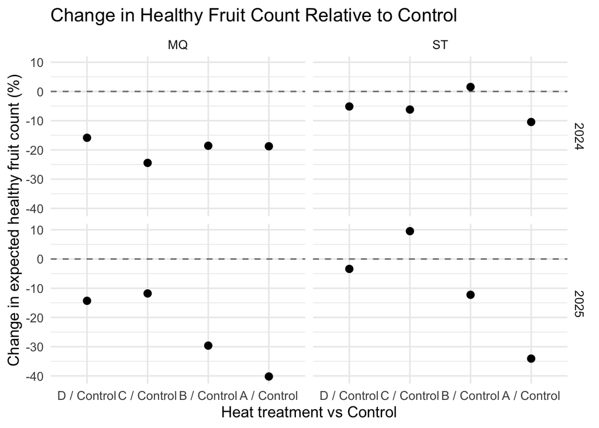

```r
plot_data$percent_change <- (plot_data$ratio - 1) * 100

ggplot(plot_data, aes(
  x = contrast,
  y = percent_change
)) +
  geom_hline(yintercept = 0, linetype = "dashed",
             color = "gray50") +
  geom_point(size = 2.5) +
  facet_grid(year ~ cultivar) +
  labs(
    title = "Change in Healthy Fruit Count Relative to Control",
    x = "Heat treatment vs Control",
    y = "Change in expected healthy fruit count (%)"
  ) +
  theme_minimal(base_size = 13)
```

How big is the difference between the controls and the heat treatments ? - contrast above shows it and there is a plot too ( TODO : look into the plot more)

```r
# Fixed-effect estimates
coefs <- summary(m1)$coefficients$cond

# Odds ratios
OR <- exp(coefs[, "Estimate"])

# 95% confidence intervals
CI <- exp(
  cbind(
    Lower = coefs[, "Estimate"] - 1.96 * coefs[, "Std. Error"],
    Upper = coefs[, "Estimate"] + 1.96 * coefs[, "Std. Error"]
  )
)

results <- data.frame(
  Term = rownames(coefs),
  Odds_Ratio = OR,
  CI_Lower = CI[, "Lower"],
  CI_Upper = CI[, "Upper"],
  p_value = coefs[, "Pr(>|z|)"]
)

#results
results_formatted <- results
results_formatted$Odds_Ratio <- sprintf("%.2f", results_formatted$Odds_Ratio)
results_formatted$CI_Lower   <- sprintf("%.2f", results_formatted$CI_Lower)
results_formatted$CI_Upper   <- sprintf("%.2f", results_formatted$CI_Upper)

# Format p-values (e.g., change small numbers to < 0.001)
results_formatted$p_value <- ifelse(
  results_formatted$p_value < 0.001,
  "< 0.001",
  sprintf("%.3f", results_formatted$p_value)
)

# 2. Print styled table
kable(
  results_formatted,
  col.names = c("Term", "Odds Ratio", "95% CI Lower", "95% CI Upper", "p-value"),
  align = c("l", "r", "r", "r", "r"),
  caption = "Model Odds Ratios and 95% Confidence Intervals"
)
```

|  | Term | Odds Ratio | 95% CI Lower | 95% CI Upper | p-value |
| --- | --- | --- | --- | --- | --- |
| (Intercept) | (Intercept) | 636.41 | 551.99 | 733.74 | < 0.001 |
| heat_groupD | heat_groupD | 0.88 | 0.77 | 1.01 | 0.063 |
| heat_groupC | heat_groupC | 0.89 | 0.78 | 1.02 | 0.091 |
| heat_groupB | heat_groupB | 0.86 | 0.75 | 0.99 | 0.037 |
| heat_groupA | heat_groupA | 0.74 | 0.64 | 0.85 | < 0.001 |
| cultivarST | cultivarST | 0.62 | 0.53 | 0.72 | < 0.001 |
| factor(year)2025 | factor(year)2025 | 0.68 | 0.58 | 0.80 | < 0.001 |

```r
#healthy_predictions <- emmeans( model_, ~ heat_group, type = "response" )

#healthy_predictions
#plot(healthy_predictions)
#pairs(healthy_predictions)
```

```r
#pred_df <- as.data.frame(healthy_predictions)

#ggplot(pred_df, aes(x = heat_group, y = prob)) +
#  geom_point(size = 3) +
#  geom_errorbar(
#    aes(ymin = asymp.LCL, ymax = asymp.UCL),
#    width = 0.15
#  ) +
#  scale_y_continuous(
#    labels = scales::percent,
#    limits = c(0, 1)
#  ) +
#  labs(
#    x = "Heat treatment",
#    y = "Predicted healthy berries (%)",
#    title = "Effect of heat stress on healthy berry percentage"
#  ) +
#  theme_minimal()

## Q : how big of a diff bet control and avg of the 4 heat intensity
```

## 7) How does heat stress affect yield as measured by the percentage of healthy fruit by weight?

binomial model underpredict heritabiltiy

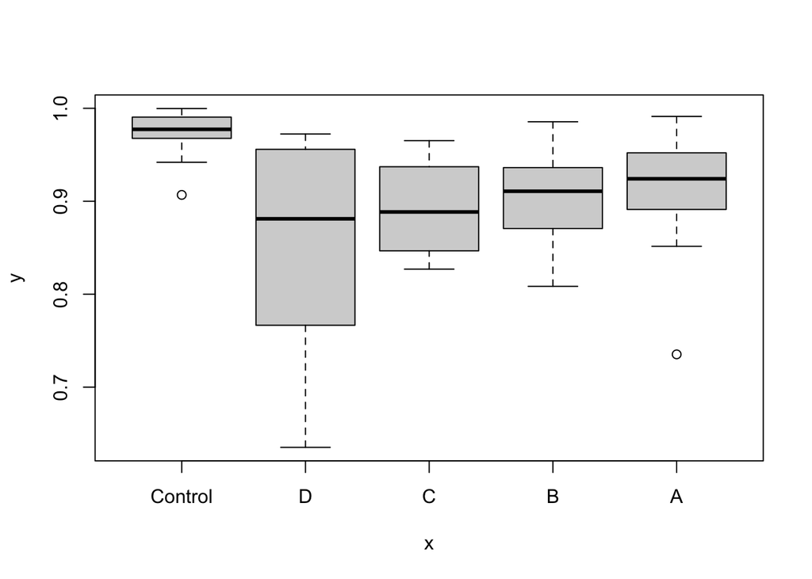

```r
data$healthy_weight_prop <-
  (data$healthy_weight / (data$total_weight))

plot(as.factor(data$heat_group), data$healthy_weight_prop)
```

```r
m4 <- glmmTMB(
  healthy_weight_prop ~
    heat_group + cultivar + factor(year) +
    (1 | pair_id),
  family = beta_family(link = "logit"),
  data = data
)


summary(m4)
```

```
##  Family: beta  ( logit )
## Formula:          healthy_weight_prop ~ heat_group + cultivar + factor(year) +
##     (1 | pair_id)
## Data: data
##
##       AIC       BIC    logLik -2*log(L)  df.resid
##    -392.9    -369.8     205.4    -410.9        87
##
## Random effects:
##
## Conditional model:
##  Groups  Name        Variance Std.Dev.
##  pair_id (Intercept) 0.06685  0.2586
## Number of obs: 96, groups:  pair_id, 48
##
## Dispersion parameter for beta family (): 41.8
##
## Conditional model:
##                  Estimate Std. Error z value Pr(>|z|)
## (Intercept)       3.32263    0.20713  16.041  < 2e-16 ***
## heat_groupD      -1.67928    0.24953  -6.730 1.70e-11 ***
## heat_groupC      -1.46072    0.20468  -7.137 9.56e-13 ***
## heat_groupB      -1.35435    0.21442  -6.316 2.68e-10 ***
## heat_groupA      -1.20608    0.25170  -4.792 1.65e-06 ***
## cultivarST        0.60925    0.14287   4.264 2.01e-05 ***
## factor(year)2025  0.01113    0.14115   0.079    0.937
## ---
## Signif. codes:  0 '***' 0.001 '**' 0.01 '*' 0.05 '.' 0.1 ' ' 1
```

```r
weight_predictions <- emmeans(m4, ~ heat_group, type = "response")
print(weight_predictions)
```

```
##  heat_group response     SE  df asymp.LCL asymp.UCL
##  Control       0.974 0.0046 Inf     0.964     0.982
##  D             0.876 0.0166 Inf     0.839     0.905
##  C             0.898 0.0157 Inf     0.863     0.925
##  B             0.907 0.0142 Inf     0.875     0.931
##  A             0.919 0.0129 Inf     0.890     0.941
##
## Results are averaged over the levels of: cultivar, year
## Confidence level used: 0.95
## Intervals are back-transformed from the logit scale
```

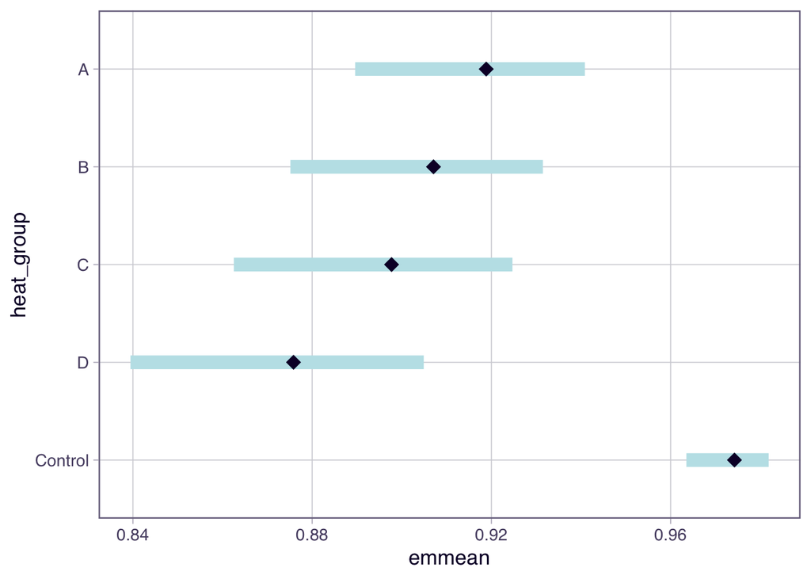

```r
plot(weight_predictions)
```

```r
#plot(simulateResiduals(m4))

# Fixed-effect estimates
coefs <- summary(m4)$coefficients$cond

# Odds ratios
OR <- exp(coefs[, "Estimate"])

# 95% confidence intervals
CI <- exp(
  cbind(
    Lower = coefs[, "Estimate"] - 1.96 * coefs[, "Std. Error"],
    Upper = coefs[, "Estimate"] + 1.96 * coefs[, "Std. Error"]
  )
)

results <- data.frame(
  Term = rownames(coefs),
  Odds_Ratio = OR,
  CI_Lower = CI[, "Lower"],
  CI_Upper = CI[, "Upper"],
  p_value = coefs[, "Pr(>|z|)"]
)

results
```

```
##                              Term Odds_Ratio   CI_Lower   CI_Upper      p_value
## (Intercept)           (Intercept) 27.7331821 18.4792710 41.6211976 6.600558e-58
## heat_groupD           heat_groupD  0.1865089  0.1143660  0.3041600 1.698841e-11
## heat_groupC           heat_groupC  0.2320683  0.1553789  0.3466089 9.555779e-13
## heat_groupB           heat_groupB  0.2581160  0.1695493  0.3929468 2.679090e-10
## heat_groupA           heat_groupA  0.2993679  0.1827910  0.4902930 1.653208e-06
## cultivarST             cultivarST  1.8390479  1.3898800  2.4333736 2.005567e-05
## factor(year)2025 factor(year)2025  1.0111895  0.7668041  1.3334620 9.371646e-01
```

```r
healthy_predictions <- emmeans(
  m4,
  ~ heat_group,
  type = "response"
)

healthy_predictions
```

```
##  heat_group response     SE  df asymp.LCL asymp.UCL
##  Control       0.974 0.0046 Inf     0.964     0.982
##  D             0.876 0.0166 Inf     0.839     0.905
##  C             0.898 0.0157 Inf     0.863     0.925
##  B             0.907 0.0142 Inf     0.875     0.931
##  A             0.919 0.0129 Inf     0.890     0.941
##
## Results are averaged over the levels of: cultivar, year
## Confidence level used: 0.95
## Intervals are back-transformed from the logit scale
```

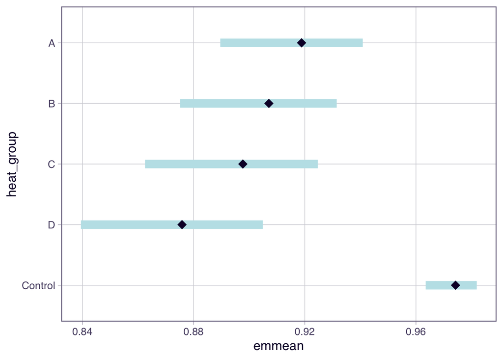

```r
plot(healthy_predictions)
```

```r
pairs(healthy_predictions)
```

```
##  contrast    odds.ratio    SE  df null z.ratio p.value
##  Control / D      5.362 1.340 Inf    1   6.730 <0.0001
##  Control / C      4.309 0.882 Inf    1   7.137 <0.0001
##  Control / B      3.874 0.831 Inf    1   6.316 <0.0001
##  Control / A      3.340 0.841 Inf    1   4.792 <0.0001
##  D / C            0.804 0.191 Inf    1  -0.920  0.8893
##  D / B            0.723 0.168 Inf    1  -1.394  0.6317
##  D / A            0.623 0.141 Inf    1  -2.086  0.2260
##  C / B            0.899 0.203 Inf    1  -0.471  0.9899
##  C / A            0.775 0.191 Inf    1  -1.034  0.8399
##  B / A            0.862 0.210 Inf    1  -0.609  0.9737
##
## Results are averaged over the levels of: cultivar, year
## P value adjustment: tukey method for comparing a family of 5 estimates
## Tests are performed on the log odds ratio scale
```

```r
#pred_df <- as.data.frame(healthy_predictions)

#ggplot(pred_df, aes(x = heat_group, y = prob)) +
#  geom_point(size = 3) +
#  geom_errorbar(
#    aes(ymin = asymp.LCL, ymax = asymp.UCL),
#    width = 0.15
#  ) +
#  scale_y_continuous(
#    labels = scales::percent,
#    limits = c(0, 1)
#  ) +
#  labs(
#    x = "Heat treatment",
#    y = "Predicted healthy berries (%)",
#    title = "Effect of heat stress on healthy berry percentage"
#  ) +
#  theme_minimal()


data$total_weight <- data$healthy_weight + data$rotten_weight
data$healthy_weight_prop <- data$healthy_weight / data$total_weight

# 2. Adjust boundaries if exact 0 or 1 values exist
N <- nrow(data)
data$healthy_weight_prop_adj <- ifelse(
  data$healthy_weight_prop %in% c(0, 1),
  (data$healthy_weight_prop * (N - 1) + 0.5) / N,
  data$healthy_weight_prop
)

# 3. Fit Beta GLMM
m4 <- glmmTMB(
  healthy_weight_prop_adj ~ heat_group + cultivar + factor(year) + (1 | pair_id),
  family = beta_family(link = "logit"),
  data = data
)

# 4. Output summary
summary(m4)
```

```
##  Family: beta  ( logit )
## Formula:
## healthy_weight_prop_adj ~ heat_group + cultivar + factor(year) +
##     (1 | pair_id)
## Data: data
##
##       AIC       BIC    logLik -2*log(L)  df.resid
##    -392.9    -369.8     205.4    -410.9        87
##
## Random effects:
##
## Conditional model:
##  Groups  Name        Variance Std.Dev.
##  pair_id (Intercept) 0.06685  0.2586
## Number of obs: 96, groups:  pair_id, 48
##
## Dispersion parameter for beta family (): 41.8
##
## Conditional model:
##                  Estimate Std. Error z value Pr(>|z|)
## (Intercept)       3.32263    0.20713  16.041  < 2e-16 ***
## heat_groupD      -1.67928    0.24953  -6.730 1.70e-11 ***
## heat_groupC      -1.46072    0.20468  -7.137 9.56e-13 ***
## heat_groupB      -1.35435    0.21442  -6.316 2.68e-10 ***
## heat_groupA      -1.20608    0.25170  -4.792 1.65e-06 ***
## cultivarST        0.60925    0.14287   4.264 2.01e-05 ***
## factor(year)2025  0.01113    0.14115   0.079    0.937
## ---
## Signif. codes:  0 '***' 0.001 '**' 0.01 '*' 0.05 '.' 0.1 ' ' 1
```

```r
library(emmeans)

pred <- emmeans(
  m2,
  ~ heat_group,
  type = "response"
)

summary(pred)
```

```
##  heat_group response   SE  df asymp.LCL asymp.UCL
##  Control         409  9.9 Inf       391       429
##  D               368 17.7 Inf       335       405
##  C               371 17.9 Inf       337       407
##  B               347 16.7 Inf       316       381
##  A               300 14.5 Inf       273       330
##
## Results are averaged over the levels of: cultivar, year
## Confidence level used: 0.95
## Intervals are back-transformed from the log scale
```

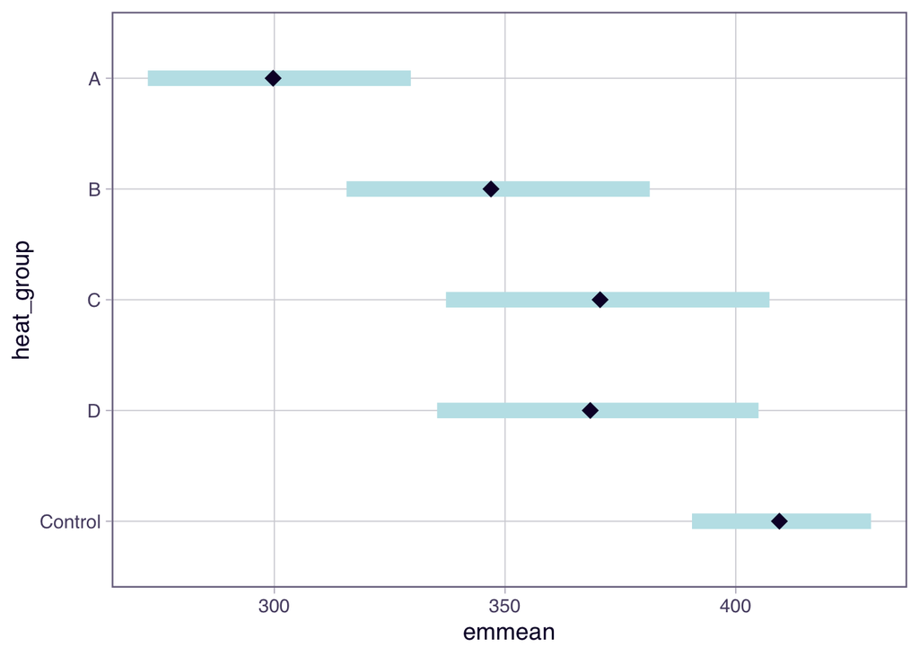

```r
plot(pred)
```

```r
pred_by_cultivar <- emmeans(
  m2,
  ~ heat_group | cultivar,
  type = "response"
)

summary(pred_by_cultivar)
```

```
## cultivar = MQ:
##  heat_group response   SE  df asymp.LCL asymp.UCL
##  Control         544 18.3 Inf       509       581
##  D               460 30.6 Inf       404       524
##  C               443 29.5 Inf       389       505
##  B               411 27.5 Inf       361       469
##  A               379 25.4 Inf       332       432
##
## cultivar = ST:
##  heat_group response   SE  df asymp.LCL asymp.UCL
##  Control         308 10.7 Inf       288       330
##  D               295 20.3 Inf       258       338
##  C               310 21.7 Inf       270       356
##  B               293 20.7 Inf       255       336
##  A               237 16.6 Inf       207       272
##
## Results are averaged over the levels of: year
## Confidence level used: 0.95
## Intervals are back-transformed from the log scale
```

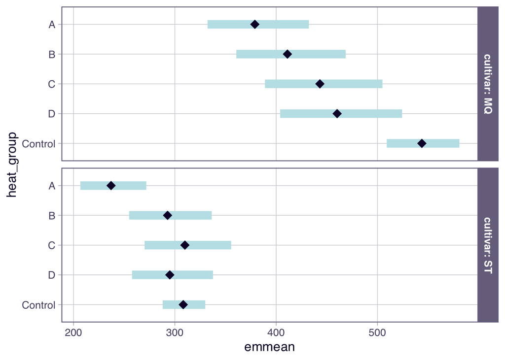

```r
plot(pred_by_cultivar)
```

```r
m3 <- glmmTMB(
  cbind(healthy_n, rotten_n) ~
    heat_group + cultivar + factor(year) +
    (1 | pair_id),
  family = betabinomial(link = "logit"),
  data = data
)
summary(m3)
```

```
##  Family: betabinomial  ( logit )
## Formula:
## cbind(healthy_n, rotten_n) ~ heat_group + cultivar + factor(year) +
##     (1 | pair_id)
## Data: data
##
##       AIC       BIC    logLik -2*log(L)  df.resid
##     858.1     881.2    -420.1     840.1        87
##
## Random effects:
##
## Conditional model:
##  Groups  Name        Variance Std.Dev.
##  pair_id (Intercept) 0.06791  0.2606
## Number of obs: 96, groups:  pair_id, 48
##
## Dispersion parameter for betabinomial family (): 44.3
##
## Conditional model:
##                  Estimate Std. Error z value Pr(>|z|)
## (Intercept)        3.0034     0.1570  19.126  < 2e-16 ***
## heat_groupD       -1.2895     0.1919  -6.720 1.81e-11 ***
## heat_groupC       -1.2591     0.1708  -7.369 1.71e-13 ***
## heat_groupB       -1.2888     0.1700  -7.580 3.45e-14 ***
## heat_groupA       -1.4349     0.1874  -7.658 1.89e-14 ***
## cultivarST         0.1702     0.1272   1.338   0.1809
## factor(year)2025  -0.2635     0.1273  -2.070   0.0385 *
## ---
## Signif. codes:  0 '***' 0.001 '**' 0.01 '*' 0.05 '.' 0.1 ' ' 1
```

```r
model <- glmmTMB(
  cbind(healthy_count_pct, (data$healthy_n + data$rotten_n) - healthy_n) ~ heat_group + cultivar + (1 | pair_id),
  family = betabinomial(link = "logit"),
  data = data
)
summary(model)
```

```
##  Family: betabinomial  ( logit )
## Formula:
## cbind(healthy_count_pct, (data$healthy_n + data$rotten_n) - healthy_n) ~
##     heat_group + cultivar + (1 | pair_id)
## Data: data
##
##       AIC       BIC    logLik -2*log(L)  df.resid
##     794.4     814.9    -389.2     778.4        88
##
## Random effects:
##
## Conditional model:
##  Groups  Name        Variance Std.Dev.
##  pair_id (Intercept) 0.04434  0.2106
## Number of obs: 96, groups:  pair_id, 48
##
## Dispersion parameter for betabinomial family (): 19.2
##
## Conditional model:
##             Estimate Std. Error z value Pr(>|z|)
## (Intercept)   1.2425     0.1116  11.137  < 2e-16 ***
## heat_groupD  -1.2982     0.1768  -7.344 2.07e-13 ***
## heat_groupC  -1.3009     0.1736  -7.494 6.68e-14 ***
## heat_groupB  -1.2534     0.1739  -7.208 5.66e-13 ***
## heat_groupA  -1.2686     0.1842  -6.888 5.65e-12 ***
## cultivarST    0.6207     0.1262   4.919 8.70e-07 ***
## ---
## Signif. codes:  0 '***' 0.001 '**' 0.01 '*' 0.05 '.' 0.1 ' ' 1
```

```r
library(emmeans)

# Predicted healthy-berry probabilities for each heat group
emm_heat <- emmeans(
  model,
  ~ heat_group,
  type = "response"
)
# Display results
summary(emm_heat)
```

```
##  heat_group response     SE  df asymp.LCL asymp.UCL
##  Control       0.825 0.0142 Inf     0.796     0.851
##  D             0.563 0.0371 Inf     0.490     0.634
##  C             0.563 0.0381 Inf     0.487     0.635
##  B             0.574 0.0372 Inf     0.500     0.645
##  A             0.571 0.0384 Inf     0.494     0.644
##
## Results are averaged over the levels of: cultivar
## Unknown transformation "(": no transformation done
## Confidence level used: 0.95
```

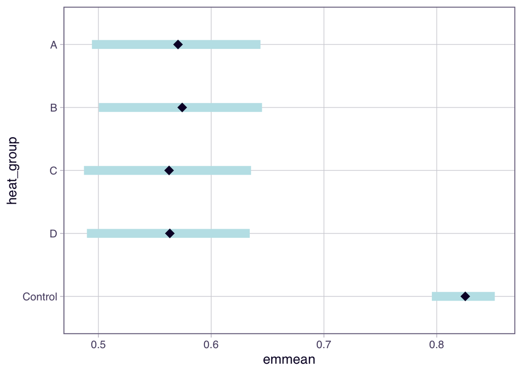

```r
plot(emm_heat)
```

```r
data_treatment <- data %>% filter(treatment != "CONTROL")






data$rotten_count_pct <- with(data, 100*rotten_n / (healthy_n + rotten_n))
data$healthy_weight_pct <- with(data, 100 * healthy_weight / total_weight)
data$rotten_weight_pct <- with(data, 100* rotten_weight / total_weight)


with(data, table(year, cultivar, heat_group))
```

```
## , , heat_group = Control
##
##       cultivar
## year   MQ ST
##   2024 12 12
##   2025 12 12
##
## , , heat_group = D
##
##       cultivar
## year   MQ ST
##   2024  3  3
##   2025  3  3
##
## , , heat_group = C
##
##       cultivar
## year   MQ ST
##   2024  3  3
##   2025  3  3
##
## , , heat_group = B
##
##       cultivar
## year   MQ ST
##   2024  3  3
##   2025  3  3
##
## , , heat_group = A
##
##       cultivar
## year   MQ ST
##   2024  3  3
##   2025  3  3
```

[figure not shown]

```r
ggplot(data, aes(
  x = heat_group,
  y = rotten_count_pct,
  fill = heat_group
)) +
  geom_boxplot(alpha = 0.7, outlier.shape = NA) +
  geom_jitter(width = 0.12, alpha = 0.6, size = 2) +
  facet_grid(year ~ cultivar) +
  labs(
    x = "Heat Treatment",
    y = "Healthy Berry Percentage (%)",
    title = "Healthy Berry Percentage by Cultivar, Year, and Treatment"
  ) +
  theme_minimal() +
  theme(legend.position = "none")
```

3. How does heat stress affect yield as measured by the percentage of healthy berries by count?

## 9) Reference